# From Likes to Change: Assessing the Impact of Citizen Engagement on the European Commission’s Social Media Platforms

Tanase Tasențe

1  
tanase.tasente@365.univ-ovidius.ro

Cristian Opariuc-Dan

1,2

Cristina Dana Popescu

1

Abstract

This study investigates the role of emotional resonance in social media communications from the European Commission (EC) and its impact on public participation across various platforms including Facebook, Instagram, Twitter, and YouTube. Findings indicate that emotionally resonant communications significantly enhance public engagement, with variations depending on the specific platform. Both positive and negative emotional resonance significantly impact participation, with the latter having a more pronounced effect. Our research highlights the critical importance of platform-specific strategies and the incorporation of emotional resonance in public communications to foster participation in policy dialogues. An analysis of the engagement rates and sentiment across platforms reveals unique tonal variations in the EC’s discourse. The effect of emotional resonance on public engagement is also found to be moderated by the choice of social media platform, with certain platforms more significantly moderating the relationship between emotional resonance and engagement than others. This study lays the groundwork for refining communication strategies within a multi-platform digital governance environment.

# Introduction

In recent years, the rise of social media platforms has led to significant changes in the way institutions, including public organizations, communicate with their audiences. As a result, the importance of citizen engagement in the process of communication through social media has become increasingly recognized. This engagement involves not only a one-way flow of information from public institutions to citizens, but also an interactive dialogue between the two parties.

The concept of engagement in social media has been studied extensively in recent years, with researchers exploring various aspects of this phenomenon. One such study, conducted by Dolan et al. (2016), approached social media engagement behavior from a uses and gratifications perspective, focusing on the motivations and benefits that users derive from engaging with social media. Meanwhile, the study by Dragseth (2020) explored how social media can be used to build engagement among students in the context of political science education.

Another important aspect of engagement in social media is the role it plays in activation campaigns aimed at consumers. Mirbagheri & Najmi (2019) conceptualized and developed a scale to measure consumers’ engagement with social media activation campaigns. Additionally, Smith & Gallicano (2015) analyzed public engagement with organizations through social media, highlighting the importance of two-way communication between public institutions and citizens.

The differentiating role of platform type in engagement with social media and social media advertising was explored by Voorveld et al. (2018), who found that the level of engagement varies across different social media platforms.

In addition to understanding the various aspects of engagement in social media, it is also important to recognize the significance of citizen engagement in the context of public institutions. Citizen engagement plays a critical role in ensuring transparency and accountability in public decision-making processes. Furthermore, engagement with citizens can lead to the development of more effective policies and programs that better serve the needs of the community.

Moreover, the importance of citizen engagement in the process of communication through social media cannot be overstated. Through social media, public institutions can engage in an interactive dialogue with citizens, build trust, and develop more effective policies and programs. As such, further research, and exploration of the concept of engagement in social media is critical for ensuring that public institutions continue to effectively communicate with and serve the needs of their communities.

Citizen engagement through social media can also contribute to the empowerment of individuals and groups, giving them a voice in public decision-making processes and enabling them to hold public institutions accountable for their actions. This can help to build stronger, more resilient communities that are better equipped to respond to challenges and opportunities.

It is also important to note that while social media has the potential to be a powerful tool for citizen engagement, there are also challenges and risks associated with its use. These include issues related to privacy, security, and the spread of misinformation and disinformation. As such, public institutions must be mindful of these risks and take steps to mitigate them, while also leveraging the power of social media to engage with citizens in a meaningful way.

Overall, the rise of social media has transformed the way public institutions communicate with citizens, placing a greater emphasis on engagement and two-way communication. Understanding the various aspects of engagement in social media is critical for public institutions to effectively communicate with and serve the needs of their communities. By leveraging the power of social media to engage with citizens, public institutions can build trust, empower individuals and groups, and develop more effective policies and programs that better serve the needs of the community.

## Literature review

In studying the impact of citizen engagement on the European Commission’s social media platforms, it is crucial to discern the key concepts that underpin this research. These concepts are engagement, social media platforms, and sentiment analysis, which form the backbone of many academic discourses that revolve around these themes.

Engagement, defined as the active interaction of users with digital content, is a fundamental element of any effective social media strategy. It encapsulates various forms of participation, from comments and shares to likes and views (Mirbagheri & Najmi, 2019). Smith & Gallicano (2015) argue that engagement helps in establishing profound relationships with users, and it can vary according to the type of platform (Voorveld et al., 2018). The concept has found applicability in numerous contexts, including public health (Heldman et al., 2013), student learning (Dragseth, 2020), and corporate social responsibility (Doncel-Martín et al. (2023)].

The significance of engagement reaches a higher dimension in the political and public sphere. With social media platforms becoming an integral part of contemporary political communication (Flew & Iosifidis, 2020; Krzyżanowski, 2020), citizen engagement has become paramount, as seen in the activities of European Union (EU) agencies (Müller, 2022). There is a myriad of ways in which citizens engage with politics on social media, from commenting on posts to sharing and liking content (De Wilde et al., 2022). This interaction has been correlated with a spectrum of outcomes, such as influencing voting behavior (Marquart et al., 2020) and attitudes towards vaccination (Mascherini & Nivakoski, 2022).

Simultaneously, social media platforms are becoming recognized as powerful tools for promoting and managing engagement. This dual role is exemplified in the case of the European Commission’s activities in Romania (Rus et al., 2021). Recognizing the potential of these platforms to facilitate citizen engagement, EU institutions have taken steps to optimize their use, implementing various strategies (Bene et al., 2022; Kanol & Nat, 2021; Özdemir & Rauh, 2022).

In assessing the impact of citizen engagement on the EU’s social media platforms, researchers employ an assortment of methods, one of which is sentiment analysis. This approach, which involves the systematic identification and categorization of the emotional tone behind words, aims to gauge public sentiment, attitudes, and emotions towards specific topics (Wei et al., 2021). It has been applied in diverse contexts, such as analyzing the emotional distribution in EU smart city communication (Kowalik, 2021) and exploring public opinions on climate change policy (Wei et al., 2021).

The European Union’s social media landscape is remarkably complex, as shown by numerous studies. These platforms can simultaneously facilitate positive engagement, such as public service promotion (Hancu-Budui et al., 2020), and breed negative phenomena like hate speech (Doncel-Martín et al., 2023) and digital vigilantism (Allen & van Zyl, 2020). Furthermore, the influence of these platforms is shaped by broader societal and political developments, such as migration and smuggling across virtual borders (Bankston, 2021).

To sum up, understanding the impact of citizen engagement on the European Commission’s social media platforms is a multifaceted issue. These platforms offer opportunities for meaningful citizen engagement and public communication, but their influence is dictated by a complex interplay of individual behavior, institutional strategy, societal trends, and technological developments. This complexity calls for a nuanced understanding of each constituent factor and their collective role in shaping the landscape of citizen engagement within the context of the European Commission’s social media platforms. It is a call to researchers, policymakers, and practitioners to continuously explore this evolving realm to maximize the benefits of citizen engagement while mitigating its potential pitfalls.

# The present study

Relying on the theoretical framework previously described, the present study aimed to investigate public engagement across various official European Commission social media platforms (Facebook, Instagram, Twitter, and YouTube). We also compared and contrasted the patterns, trends, and characteristics of online user interactions and responses across these platforms. Translating these aims into research questions (RQs), the present study investigated the following:

- *RQ<sub>1</sub>*. How is the communication with emotional resonance associated with higher public engagement levels?
- *RQ<sub>2</sub>*. Does social media platforms influences the emotional resonance on public engagement?
- *RQ<sub>3</sub>*. Does social media platforms moderates the effect of emotional resonance on public engagement?

To answer these questions, we assumed the following:

- *H<sub>1</sub>*: Communications with emotional resonance are associated with higher public engagement levels.
- *H<sub>2</sub>*: Social media platform influences the emotional resonance on public engagement.
- *H<sub>3</sub>*: The effect of emotional resonance on public engagement is moderated by the social media platform utilized.

The novelty of our study lies in the fact that we have systematically compared and contrasted user engagement and emotional resonance across multiple social media platforms utilized by the European Commission. While previous research has generally focused on the impact of citizen engagement within a single social media platform, our study is unique in its comprehensive cross-platform analysis.

In this context, we have pursued an integrated approach to understanding how emotional resonance can influence public engagement levels across these platforms. Furthermore, we have explored the moderating effect of the social media platform itself on the impact of emotional resonance, a novel aspect that has not been fully addressed in previous research.

The innovative approach of this study allowed us to draw robust conclusions about the nuanced relationship between communication strategy, emotional resonance, platform choice, and public engagement. Our research has therefore not only provided key insights into the patterns of citizen engagement on European Commission’s social media platforms, but also presented an advanced framework for understanding how such engagement can be effectively harnessed and maximized for public outreach and policymaking.

Ultimately, this study has expanded the current discourse in the field of digital communication and citizen engagement, and opened up new avenues for future research on optimizing communication strategies in a multi-platform social media environment.

# Method

## Procedure used for data gathering

We used the Fanpagekarma, a prevalent tool for conducting analytics and monitoring on social media platforms to extract data for the official Facebook, Twitter, Instagram, and YouTube channels of the European Commission. The data included post ID, message content, post type, post date, number of likes, comments, shares, and the rounded figure of followers for each post made by the European Commission, in the period from feb 2019 to apr 2023.

The engagement rate metric is commonly employed to gauge the extent of audience interaction with a brand or organization on social media platforms, and total number of reactions (comprising likes, comments, and shares) were calculated, and divided by the total follower count. A sentiment analysis method was used on engagement rate to reveal the trends and a linear regression analysis was conducted to test the hypothesis.

# Results

## Overview of data analysis

We used R (Version 4.3.0; R Core Team, 2023) and the R-packages *boot* (Version 1.3.28.1; Davison & Hinkley, 1997), *caret* (Version 6.0.94; Kuhn & Max, 2008), *dplyr* (Version 1.1.2; Wickham et al., 2023), *flextable* (Version 0.9.1; Gohel & Skintzos, 2023), *ggplot2* (Version 3.4.2; Wickham, 2016), *ggpubr* (Version 0.6.0; Kassambara, 2023a), *interactions* (Version 1.1.5; Long, 2019), *knitr* (Version 1.43; Xie, 2015), *lattice* (Version 0.21.8; Sarkar, 2008), *lm.beta* (Version 1.7.2; Behrendt, 2023), *lubridate* (Version 1.9.2; Grolemund & Wickham, 2011), *MASS* (Version 7.3.60; Venables & Ripley, 2002), *Matrix* (Version 1.5.4.1; Bates et al., 2023), *misty* (Version 0.4.11; Yanagida, 2023), *mitools* (Version 2.4; Lumley, 2019), *mvtnorm* (Version 1.2.2; Genz & Bretz, 2009), *naniar* (Version 1.0.0; Tierney & Cook, 2023), *NLP* (Version 0.2.1; Hornik, 2020), *nortest* (Version 1.0.4; Gross & Ligges, 2015), *papaja* (Version 0.1.1; Aust & Barth, 2022), *psych* (Version 2.3.3; William Revelle, 2023), *readxl* (Version 1.4.2; Wickham & Bryan, 2023), *relaimpo* (Version 2.2.6; Grömping, 2006), *rstatix* (Version 0.7.2; Kassambara, 2023b), *sasLM* (Version 0.9.9; Bae, 2023), *SentimentAnalysis* (Version 1.3.4; Proellochs & Feuerriegel, 2021), *survey* (Version 4.2.1; Lumley, 2004), *survival* (Version 3.5.5; Terry M. Therneau & Patricia M. Grambsch, 2000), *tinylabels* (Version 0.2.3; Barth, 2022), *tm* (Version 0.7.11; Feinerer et al., 2008), and *writexl* (Version 1.4.2; Ooms, 2023) for all our analyses.

The initial assumptions assessment was performed by descriptive univariate analysis, data screening for outliers, and missing cases analysis, to verify univariate normality. We further conducted a sentiment analysis, and, finally a linear moderated regression was used for hypothesis testing.

## Preliminary analysis

Some extreme high values were identified on Facebook engagement rate (values over .00484), Instagram engagement rate (values over .0215), Twitter engagement rate (values over .000696) and Youtube engagement rate (values over .000962) and replaced with missing values, however only 5.15% scores were missing so we decided to remove entire cases.

```r
  bp.ext
```

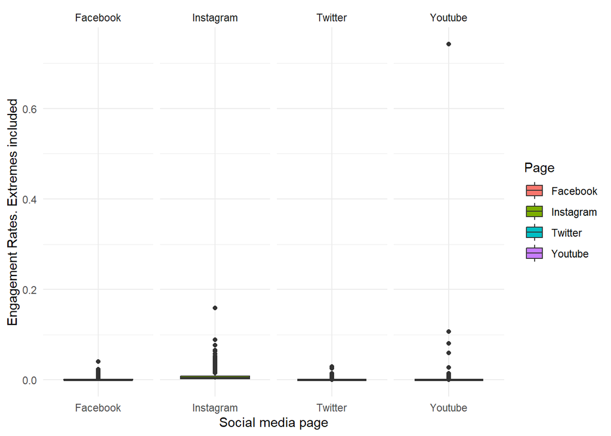

Boxplot of engagement rates on social media channels. Extremes included

```r
  st.ext
```

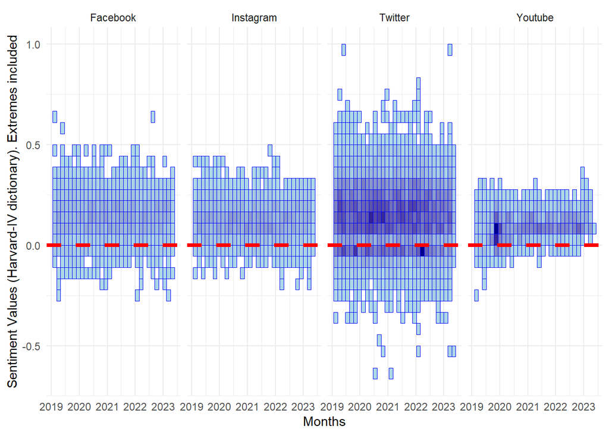

Sentiment analysis chart on social media channels. Extremes included

```r
  bp.next
```

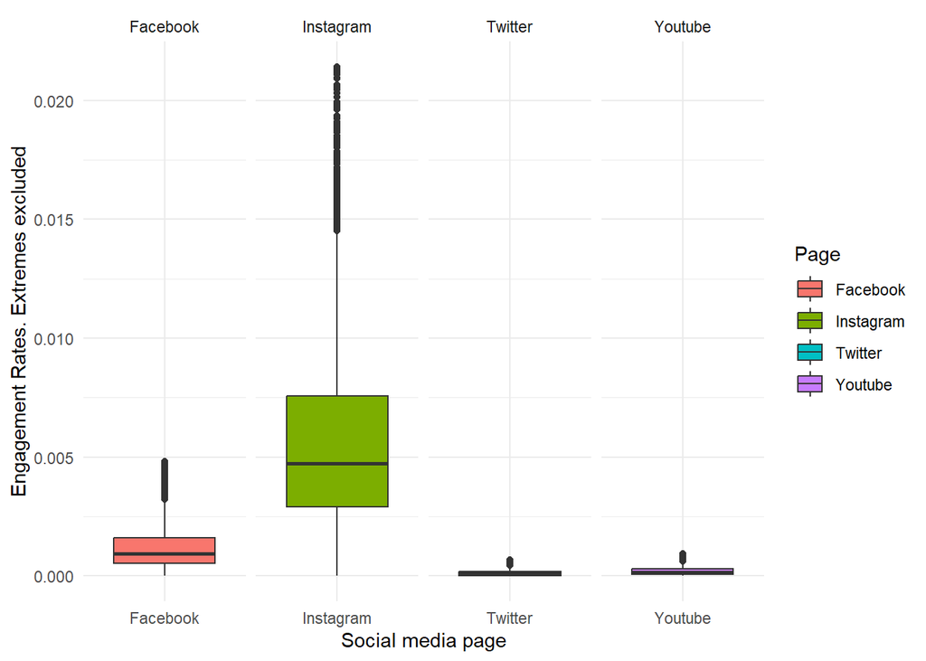

Boxplot of engagement rates on social media channels. Extremes excluded

```r
  st.next
```

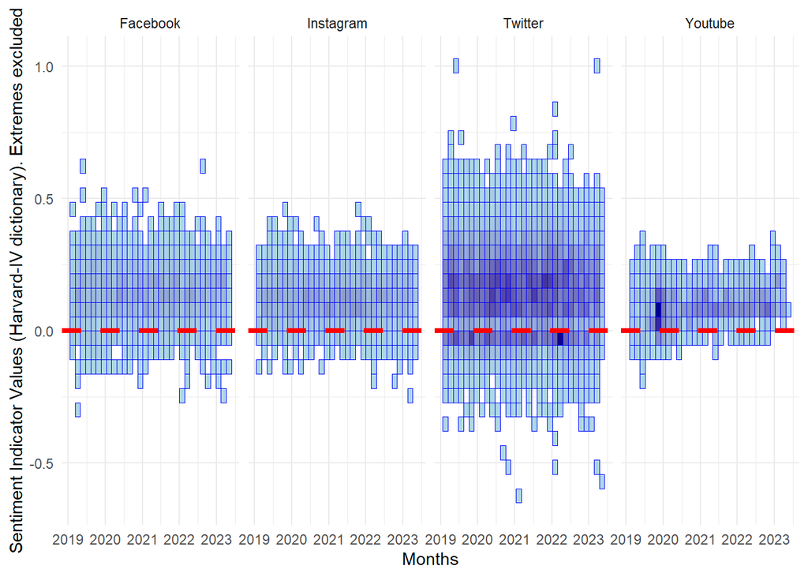

Sentiment analysis chart on social media channels. Extremes excluded

## Sentiment analysis

In the case of Facebook, the sentiment’s indicator mean value was 0.14274 (SD=0.10285), showed a tendency to a positive tone (M=0.14216, SD=0.10362 with extreme outliers). The sentiment ranged between -0.27273 and 0.63158 (-0.27273 and 0.64706 with extreme outliers), the discourse with a negative connotation averaged at 0.07989 (SD=0.0579), while the discourse with a positive undertone demonstrated a mean of 0.22263 (SD=0.08834), thereby further substantiating a propensity for positivity (M=0.07999, SD=0.05819, respectively M=0.22215, SD=0.0891 with extreme outliers).

On YouTube, the sentiment indicator’s mean value was observed to be the lowest amongst the evaluated platforms at 0.09543, spanning from -0.19231 and 0.33962 (-0.23077 and 0.33962 with extreme outliers), thereby indicating a more tempered sentiment. Negative discourse on YouTube scored the lowest mean of 0.0344 (SD=0.03407), while positive discourse registered the minimum average of 0.12963 (SD=0.06131 with extreme outliers) compared to the other platforms.

In conclusion, despite a general inclination towards a slightly positive mean sentiment across all platforms, Twitter demonstrated the most substantial sentiment range, signifying the potential for both intensely negative and positive discourse. Instagram and Facebook depicted a modestly positive sentiment with less variability, while YouTube exhibited the most tempered sentiment range, with the lowest averages for both positive and negative discourse.

The results suggested that the null hypothesis **H<sub>0</sub>:** *Communications with emotional resonance are not associated with higher public engagement levels* could be rejected (F(2, 1.2441^{4})=11.06, p < 0.001) and the *H<sub>1</sub>*: *Communications with emotional resonance are associated with higher public engagement levels* was plausible, however the engagement levels was explained only by 0.161% by the positive and negative resonance communications (R<sup>2</sup>=0.0016, RSR=0.0002).

The positive *(B=0.00004, t=2.64, p = 0.008, $\beta$=0.024)* and negative *(B=0.00010, t=3.51, p < 0.001, $\beta$=0.032)* emotional resonance communications were both positively associated statistically significant with engagement rates, and high values on emotional resonance, positive or negative, were associated with high values on engagement rates. However, the relative predictors relevance showed that negative emotional resonance (62.09%) contributed more on engagement rates explanation than positive emotional resonance (37.91%)

Furthermore, we observed that the effect of social media platform was statistically significant on all platforms compared with Twitter and the null hypothesis **H<sub>0</sub>:** *The effect of emotional resonance on public engagement is not moderated by the social media platform* could be rejected. (F(5, 1.2438^{4})=1240.04, p < 0.001). Adding the new as categorical predictor increased the prediction power at 33.239% from 0.161% (R<sup>2</sup>=0.332, RSR=0.0002), as the most relevant predictor was social network (99.61%), followed by negative emotional resonance (0.28%) and positive emotional resonance (0.12%)

Negative emotional resonance was still statistically significant positively associated by public engagement *(B=0.00008, t=3.59, p < 0.001, $\beta$=0.027)*, but not positive emotional resonance *(B=0.00001, t=1.02, p = 0.31, $\beta$=0.008)*, and compared by Twitter, engagement rates increased statistically significant on Facebook *(B=0.00038, t=77.88, p < 0.001, $\beta$=0.579)*, Instagram *(B=0.00049, t=11.07, p < 0.001, $\beta$=0.081)* and Youtube *(B=0.00005, t=12.82, p < 0.001, $\beta$=0.103)*.

Finally, the hypothesis *H<sub>3</sub>*: *The effect of emotional resonance on public engagement is moderated by the social media platform utilized* was also plausible (F(11, 1.2432^{4})=568.57, p < 0.001), the model with interaction terms explaining 33.411% of engagement rate’s variance (R<sup>2</sup>=0.334, RSR=0.0002) and had a statistically significant better prediction power than the second model (F(6, 1.2432^{4})=6.34, p < 0.001).

The main effect of negative emotional resonance was statistically significant *(B=0.00012, t=4.62, p < 0.001, $\beta$=0.038)*, but not the main effect of positive emotional resonance *(B=-0.00000, t=-0.02, p = 0.981, $\beta$=0)*, and both were moderated by social network. Furthermore, compared to Twitter influence, Facebook *(B=0.00038, t=26.45, p < 0.001, $\beta$=0.586)* and Youtube *(B=0.00004, t=4.73, p < 0.001, $\beta$=0.084)* were statistically significant positively associated with engagement rate, but not Instragram *(B=-0.00026, t=-1.39, p = 0.165, $\beta$=-0.043)*.

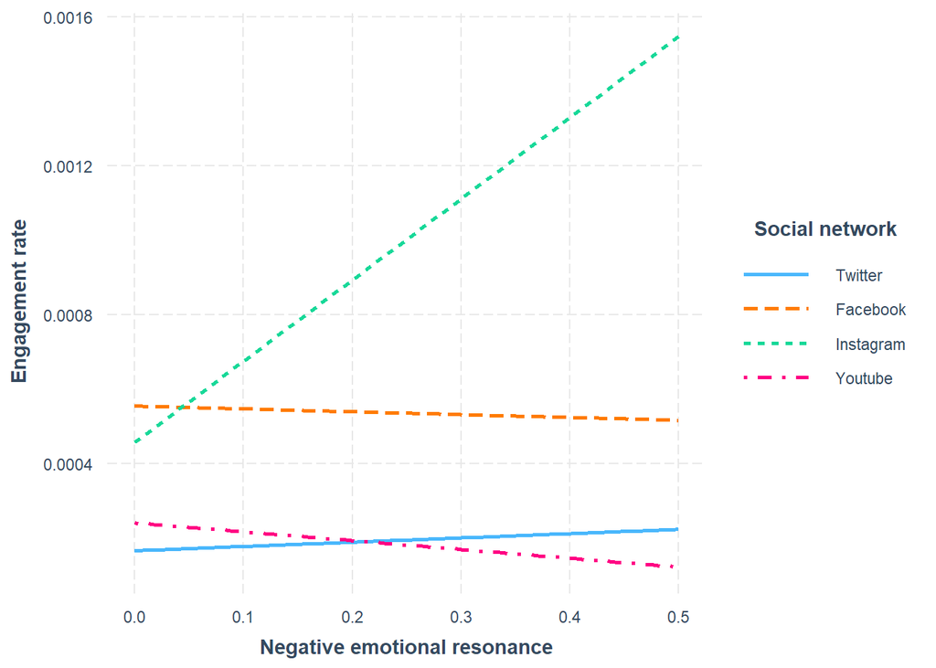

Interaction effect between social network and negative emotional resonance on engagement rate

```r
  Int.Plot.1
```

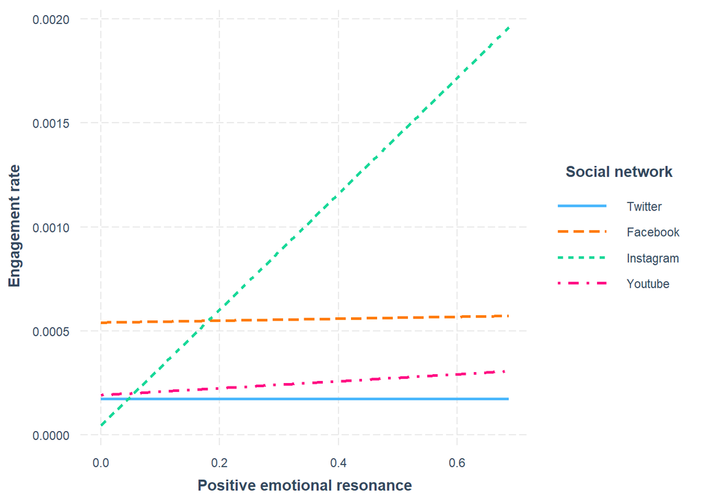

Interaction effect between social network and positive emotional resonance on engagement rate

```r
  Int.Plot.2
```

Compared to Twitter posts, if the messages with positive emotional resonance were posted on Instagram or Youtube, the engagement rate increased statistically significant and the effect was most powerfull on Instagram than on Youtube. No interaction effect was observed on Facebook related on positive emotional resonance *(B=0.00005, t=0.89, p = 0.374, $\beta$=0.018)*

# Discussion

The current study embarked on an investigative journey to examine public engagement across a range of social media platforms utilized by the European Commission, laying specific emphasis on the impact of emotional resonance within disseminated content. The vital role of social media in communication strategies of public institutions has been widely recognized (Smith & Gallicano, 2015), accentuating the necessity for an in-depth comprehension of the dynamics of engagement.

Our collected data validates our primary hypothesis (H1), implying that communications imbued with emotional resonance, regardless of its positive or negative polarity, are associated with augmented public engagement. Nevertheless, the capacity of emotional resonance to illuminate engagement levels remains marginal (0.16%). This finding is consistent with the complex nature of engagement behaviours outlined in existing academic discourse (Dolan et al., 2016; Dragseth, 2020; Mirbagheri & Najmi, 2019), thereby underscoring the need for further scrutiny of additional factors influencing public engagement.

This investigation embarked on a quest to explore public engagement across various social media platforms utilized by the European Commission, with an emphasis on the impact of emotional resonance within content. The role of social media in public institutions’ communication strategies is pivotal (Smith & Gallicano, 2015), necessitating a deep understanding of engagement dynamics.

The data supports our first hypothesis (H1), suggesting that communications rich in emotional resonance, whether of positive or negative valence, are associated with enhanced public engagement. However, the ability of emotional resonance to explain engagement levels is negligible (0.16%). This corroborates the complex nature of engagement behaviors expounded in scholarly literature (Dolan et al., 2016; Dragseth, 2020; Mirbagheri & Najmi, 2019) and points towards the necessity for further examination of supplementary factors influencing public engagement.

Our secondary hypothesis (H2) proposed that the choice of the social media platform would significantly influence the effect of emotional resonance on public engagement. The empirical evidence corroborates this assertion, indicating that different platforms potentially cater to diverse user expectations and conventions. This alignment with prior research revealing platform-specific variations in engagement patterns (Voorveld et al., 2018) underscores the necessity for the European Commission to recognize and adapt to these heterogeneous engagement patterns when designing their communication strategies.

The tertiary hypothesis (H3) posited that the chosen social media platform would moderate the impact of emotional resonance on public engagement. The acquired data affirmed this premise, demonstrating a statistically significant moderating effect. This indicates that the characteristics of individual platforms may shape the public’s interaction with emotionally resonant messages, highlighting the need to tailor such communications to align with the norms specific to each platform.

This research is constrained by its reliance on secondary data obtained from platforms, suggesting that future studies could potentially reap benefits from primary data collection methodologies. Furthermore, this study did not associate Engagement Rate (ER) with significant simultaneous events, potentially overlooking the effect of emotional reactions provoked by these events. Future investigations could probe these associations, thereby enhancing our understanding of emotional impacts and expanding the existing body of knowledge in this domain.

The third hypothesis (H3) asserted that the social media platform would moderate the impact of emotional resonance on public engagement. Our data sustained this assumption, revealing a statistically significant moderating effect. This suggests that platforms may shape the way the public interacts with emotionally resonant messages, emphasizing the importance of customizing such communications to align with each platform’s norms.

Despite these findings, the study is not without limitations. The scope of this research was confined to the European Commission’s use of four primary social media platforms. Future inquiries could potentially explore other platforms or public institutions to determine the universality of the observed patterns. Furthermore, while our focus lay primarily on emotional resonance, future research could delve into other aspects of communication, such as tone, complexity, and framing.

This research has also limitations due to the use of secondary data obtained from platforms, suggesting future studies could benefit from primary data collection. Additionally, this study did not associate Engagement Rate (ER) with significant concurrent events, potentially overlooking the impact of emotional reactions based on these events. Future studies could explore these associations to understand emotional impacts better, thus extending the existing knowledge in the field.

To conclude, this study underscores the imperative role of both emotional resonance and platform-specific norms in propelling public engagement on social media. The ability to establish an emotional connection with the audience, made possible through well-conceived and executed posts, emerges as a powerful tool for amplifying engagement levels. Such engagement is not merely about expanding the reach or visibility of public institutions like the European Commission, but is a mechanism for fostering a dynamic and participatory relationship between these institutions and the citizens they serve.

Understanding these dynamics enables public institutions to tailor their communication strategies more effectively. By acknowledging the varying norms and expectations tied to different social media platforms, institutions can ensure that their messages resonate more strongly with their intended audiences, ultimately enhancing the impact and penetration of these messages. The choice of platform is not incidental but plays a significant role in how emotional resonance influences engagement, urging public institutions to be thoughtful and strategic in their selection and use of these platforms.

Moreover, by refining their social media strategies based on these findings, public institutions have the opportunity to foster greater citizen engagement. Higher engagement can lead to increased public awareness, enhanced understanding, and potentially even behavioural change - critical goals for public communication strategies. It can also help public institutions gain insight into public sentiment, thus providing valuable feedback that can be used to improve policies and services.

In addition, the insights derived from this study can help public institutions increase the effectiveness of their public communication. By leveraging emotional resonance and considering platform-specific norms, these institutions can design messages that are more likely to engage citizens and generate a meaningful response. This has the potential to transform the landscape of public communication, making it a more interactive, responsive, and impactful domain.

Despite its limitations, this study provides an invaluable point of departure for further research into the intricate world of social media engagement. It opens up avenues for exploring other influential factors and for deepening our understanding of the relationship between emotional resonance, platform norms, and public engagement. These insights could be crucial in helping public institutions navigate the complex dynamics of social media engagement, enhancing their ability to communicate effectively with the public, and ultimately, improving their service to society.

To conclude, this study underscores the significance of emotional resonance and platform-specific norms in driving public engagement. It suggests that forming an emotional connection with the audience through posts could amplify engagement levels. By understanding these dynamics, public institutions like the European Commission can refine their social media strategies, enhance citizen engagement, and bolster the efficacy of their public communication. Despite the limitations, the study provides a valuable starting point for future research into the multifaceted world of social media engagement.

# References

Allen, K., & van Zyl, I. (2020). Digital vigilantism, social media and cyber criminality. *Paris: Enact/European Union*.

Aust, F., & Barth, M. (2022). *papaja: Prepare reproducible APA journal articles with R Markdown*. https://github.com/crsh/papaja

Bae, K.-S. (2023). *sasLM: ’SAS’ linear model*. https://CRAN.R-project.org/package=sasLM

Bankston, J. (2021). Migration and smuggling across virtual borders: A European Union case study of internet governance and immigration politics. In *Digital Identity, Virtual Borders and Social Media* (pp. 73–97). Edward Elgar Publishing.

Barth, M. (2022). *tinylabels: Lightweight variable labels*. https://cran.r-project.org/package=tinylabels

Bates, D., Maechler, M., & Jagan, M. (2023). *Matrix: Sparse and dense matrix classes and methods*. https://CRAN.R-project.org/package=Matrix

Behrendt, S. (2023). *Lm.beta: Add standardized regression coefficients to linear-model-objects*. https://CRAN.R-project.org/package=lm.beta

Bene, M., Ceron, A., Fenoll, V., Haßler, J., Kruschinski, S., Larsson, A. O., Magin, M., Schlosser, K., & Wurst, A.-K. (2022). Keep them engaged! Investigating the effects of self-centered social media communication style on user engagement in 12 European countries. *Political Communication*, *39*(4), 429–453.

Davison, A. C., & Hinkley, D. V. (1997). *Bootstrap methods and their applications*. Cambridge University Press. http://statwww.epfl.ch/davison/BMA/

De Wilde, P., Rasch, A., & Bossetta, M. (2022). Analyzing citizen engagement with European politics on social media. *Politics and Governance*, *10*(1), 90–96.

Dolan, R., Conduit, J., Fahy, J., & Goodman, S. (2016). Social media engagement behaviour: A uses and gratifications perspective. *Journal of Strategic Marketing*, *24*(3-4), 261–277.

Doncel-Martín, I., Catalan-Matamoros, D., & Elías, C. (2023). Corporate social responsibility and public diplomacy as formulas to reduce hate speech on social media in the fake news era. *Corporate Communications: An International Journal*, *28*(2), 340–352.

Dragseth, M. R. (2020). Building student engagement through social media. *Journal of Political Science Education*, *16*(2), 243–256.

Feinerer, I., Hornik, K., & Meyer, D. (2008). Text mining infrastructure in r. *Journal of Statistical Software*, *25*(5), 1–54. https://doi.org/10.18637/jss.v025.i05

Flew, T., & Iosifidis, P. (2020). Populism, globalisation and social media. *International Communication Gazette*, *82*(1), 7–25.

Genz, A., & Bretz, F. (2009). *Computation of multivariate normal and t probabilities*. Springer-Verlag.

Gohel, D., & Skintzos, P. (2023). *Flextable: Functions for tabular reporting*. https://CRAN.R-project.org/package=flextable

Grolemund, G., & Wickham, H. (2011). Dates and times made easy with lubridate. *Journal of Statistical Software*, *40*(3), 1–25. https://www.jstatsoft.org/v40/i03/

Grömping, U. (2006). Relative importance for linear regression in r: The package relaimpo. *Journal of Statistical Software*, *17*(1), 1–27.

Gross, J., & Ligges, U. (2015). *Nortest: Tests for normality*. https://CRAN.R-project.org/package=nortest

Hancu-Budui, A., Zorio-Grima, A., & Blanco-Vega, J. (2020). Audit institutions in the European Union: Public service promotion, environmental engagement and Covid crisis communication through social media. *Sustainability*, *12*(23), 9816.

Heldman, A. B., Schindelar, J., & Weaver, J. B. (2013). Social media engagement and public health communication: Implications for public health organizations being truly “social.” *Public Health Reviews*, *35*, 1–18.

Hornik, K. (2020). *NLP: Natural language processing infrastructure*. https://CRAN.R-project.org/package=NLP

Kanol, D., & Nat, M. (2021). Group type and social media engagement strategies in the EU: The case of British interest groups on Facebook. *Journal of Public and Nonprofit Affairs*, *7*(2), 205–219.

Kassambara, A. (2023a). *Ggpubr: ’ggplot2’ based publication ready plots*. https://CRAN.R-project.org/package=ggpubr

Kassambara, A. (2023b). *Rstatix: Pipe-friendly framework for basic statistical tests*. https://CRAN.R-project.org/package=rstatix

Kowalik, K. (2021). Social media as a distribution of emotions, not participation. Polish exploratory study in the EU smart city communication context. *Cities*, *108*, 102995.

Krzyżanowski, M. (2020). Digital Diplomacy or Political Communication? Exploring Social Media in The EU Institutions from a Critical Discourse Perspective 1. In *Digital Diplomacy and International Organisations* (pp. 52–73). Routledge.

Kuhn, & Max. (2008). Building predictive models in r using the caret package. *Journal of Statistical Software*, *28*(5), 1–26. https://doi.org/10.18637/jss.v028.i05

Long, J. A. (2019). *Interactions: Comprehensive, user-friendly toolkit for probing interactions*. https://cran.r-project.org/package=interactions

Lumley, T. (2004). Analysis of complex survey samples. *Journal of Statistical Software*, *9*(1), 1–19.

Lumley, T. (2019). *Mitools: Tools for multiple imputation of missing data*. https://CRAN.R-project.org/package=mitools

Marquart, F., Goldberg, A. C., & de Vreese, C. H. (2020). “This time I’m (not) voting”: A comprehensive overview of campaign factors influencing turnout at European Parliament elections. *European Union Politics*, *21*(4), 680–705.

Mascherini, M., & Nivakoski, S. (2022). Social media use and vaccine hesitancy in the European Union. *Vaccine*, *40*(14), 2215–2225.

Mirbagheri, S., & Najmi, M. (2019). Consumers’ engagement with social media activation campaigns: Construct conceptualization and scale development. *Psychology & Marketing*, *36*(4), 376–394.

Müller, M. (2022). Spreading the word? European Union agencies and social media attention. *Government Information Quarterly*, *39*(2), 101682.

Ooms, J. (2023). *Writexl: Export data frames to excel ’xlsx’ format*. https://CRAN.R-project.org/package=writexl

Özdemir, S. F., & Rauh, C. (2022). *A Bird’s eye view: Supranational EU Actors on Twitter*.

Proellochs, N., & Feuerriegel, S. (2021). *SentimentAnalysis: Dictionary-based sentiment analysis*. https://CRAN.R-project.org/package=SentimentAnalysis

R Core Team. (2023). *R: A language and environment for statistical computing*. R Foundation for Statistical Computing. https://www.R-project.org/

Rus, M., Tasente, T., & Camara, V. (2021). Social media communication of public institutions. Case study: Representation of the European Commission in Romania. *Technium Soc. Sci. J.*, *17*, 119.

Sarkar, D. (2008). *Lattice: Multivariate data visualization with r*. Springer. http://lmdvr.r-forge.r-project.org

Smith, B. G., & Gallicano, T. D. (2015). Terms of engagement: Analyzing public engagement with organizations through social media. *Computers in Human Behavior*, *53*, 82–90.

Terry M. Therneau, & Patricia M. Grambsch. (2000). *Modeling survival data: Extending the Cox model*. Springer.

Tierney, N., & Cook, D. (2023). Expanding tidy data principles to facilitate missing data exploration, visualization and assessment of imputations. *Journal of Statistical Software*, *105*(7), 1–31. https://doi.org/10.18637/jss.v105.i07

Venables, W. N., & Ripley, B. D. (2002). *Modern applied statistics with s* (Fourth). Springer. https://www.stats.ox.ac.uk/pub/MASS4/

Voorveld, H. A., Van Noort, G., Muntinga, D. G., & Bronner, F. (2018). Engagement with social media and social media advertising: The differentiating role of platform type. *Journal of Advertising*, *47*(1), 38–54.

Wei, Y., Gong, P., Zhang, J., & Wang, L. (2021). Exploring public opinions on climate change policy in" Big Data Era" case study of the European Union Emission Trading System (EU-ETS) based on Twitter. *Energy Policy*, *158*, 112559.

Wickham, H. (2016). *ggplot2: Elegant graphics for data analysis*. Springer-Verlag New York. https://ggplot2.tidyverse.org

Wickham, H., & Bryan, J. (2023). *Readxl: Read excel files*. https://CRAN.R-project.org/package=readxl

Wickham, H., François, R., Henry, L., Müller, K., & Vaughan, D. (2023). *Dplyr: A grammar of data manipulation*. https://CRAN.R-project.org/package=dplyr

William Revelle. (2023). *Psych: Procedures for psychological, psychometric, and personality research*. Northwestern University. https://CRAN.R-project.org/package=psych

Xie, Y. (2015). *Dynamic documents with R and knitr* (2nd ed.). Chapman; Hall/CRC. https://yihui.org/knitr/

Yanagida, T. (2023). *Misty: Miscellaneous functions ’t. yanagida’*. https://CRAN.R-project.org/package=misty